# Машинное обучение. ВМК МГУ

## Практическое задание 3: Knn: классификация и регрессия

### Важно! О формате сдачи

- Все задания, кроме двух на реализацию кода, в этой части оцениваются по системе кросс-рецензирования.
- При решении ноутбука используйте данный шаблон. Не нужно удалять текстовые ячейки c разметкой частей ноутбука и формулировками заданий. Добавлять свои ячейки, при необходимости, конечно можно
- Везде, где в формулировке задания есть какой-либо вопрос (или просьба вывода), необходимо прописать ответ в ячейку (код или markdown).
- Наличие кода решения обязательно. Письменные ответы на вопросы без сопутствующего кода оцениваются в 0 баллов.
- Если в ячейке написана фраза "Вывод"/"Ответ на вопрос" итд, то ожидается ответ в виде текста (можете добавить ячейки с кодом, если считаете это необходимым, но это необязательно). Если в ячейке написано "Your code here" и пр. , то ожидается ответ в виде кода (можете добавить ячейки с кодом, если считаете это необходимым, но это необязательно). Если есть и ячейка с фразой "Вывод", и ячейка с фразой "Your code here", то в ответе ожидается и код, и текст

### *Примерное время выполнения (execution time/время выполнения, если нажать run all) всех ячеек ноутбука при правильной реализации: 10 минут *

## Подготовка рабочей среды

Сначала установим нужные нам версии библиотек. Мы гарантируем, что в данных версиях задание будет корректно отрабатывать.

После установки нужных версий, **возможно,** нужно перезагрузить среду (runtime), но скорее всего вам это не понадобится

На скачивание файла и установку понадобится не более 5 минут.

**Важно!** Устанавливать нужные версии нужно каждый раз, когда создается новый рантайм. Например, если вы 2 часа подряд делаете это задание, то подготовить библиотеки достаточно 1 раз. Но если вы, например, начали в понедельник, затем закрыли/выключили ноутбук, то при продолжении в среду, вам нужно будет запустить рантайм заново и следовательно заново установить библиотеки.

**Важно!** Если вы предпочитаете делать практические задания на своем личном ноутбуке, то проверьте, что вы установили рабочее окружение в [соответствии с гайдом](https://github.com/MSU-ML-COURSE/ML-COURSE-23-24/blob/main/tutorials/Туториал%20по%20установке%20рабочего%20окружения%20в%20Python%20для%20решения%20задач.pdf)

```python
# !!! Данный блок будет работать только в Google-Colab !!!
! gdown 1qa4VOOjn88tSEAXI_f-aKRzKldMdd5xS
! pip install -r /content/requirements.txt
```

[output not shown]

Проверим версию библиотеки:

```python
import catboost
assert(catboost.__version__ == '1.2.1')
```

Теперь можно приступать к выполнению задания! :)

# Часть 0. Знакомство с библиотекой scikit-learn

`Scikit-learn` - это библиотека машинного обучения с открытым исходным кодом, которая предоставляет различные инструменты для предобработки данных и обучения моделей.

Каждый **модуль предобработки** данных имеет два метода: `fit` и `transform`.

- Как правило, метод `fit` принимает на вход **обучающую** выборку $X$ и считает по ней необходимые для заданного типа преобразования статистики.
- Метод `transform` преобразует входные данные, используя статистики, посчитанные при вызове метода `fit` и возвращает преобразованные данные.

Выборка $X$ представляется в виде матрицы размера `(n_samples, n_features)`, то есть каждому *объекту* соответствует отдельная строка, а каждому *признаку* - отдельный столбец.

Каждая **модель машинного обучения** имеет два метода: `fit` - метод ответственный за обучения модели и `predict` - метод ответственный за предсказание целевой переменной.

- Как правило, метод `fit` принимает на вход два аргумента: $X$ - **обучающая** выборка, $y$ - значения целевых переменных на объектах обучающей выборки.
- Метод `predict` принимает на вход набор данных и выдает предсказанные значения целевых переменных на этом наборе данных.
- В моделях классификации бывает метод `predict_proba`, который принимает на вход набор данных и выдает вероятности принадлежности классам.

Если нами решается задача *классификации*, то вектор целевых переменных $y$ содержит целые числа (или другое множество дискретных величин). При решении задачи *регрессии* вектор $y$ содержит вещественные числа.

Более подробно про библиотеку можно прочитать в документации по [ссылке](https://scikit-learn.org/stable/index.html)

Приведем пример стандартной работы с библиотекой scikit-learn

```python
#Создаем обучающую выборку
X = [[0], [1], [2], [3]]
y = [0, 0, 1, 1]

#Делаем импорт класса K-NN классификатора
from sklearn.neighbors import KNeighborsClassifier

#Создаем объект класса 3-NN классификатора
neigh = KNeighborsClassifier(n_neighbors=3)

#Обучаем классифкатора на созданной ранее выборке
neigh.fit(X, y)

#Предсказываем метку класса нового объекта с помощью метода predict
print(neigh.predict([[1.1]]))
```

```
[0]
```

# Часть 1. Нормализация признакового пространства

В задачах машинного обучения важную роль играет нормализация данных. Для числовых признаков, как правило, используют два типа нормализации:

- **Нормализация к распределению с нулевым матожиданием** и единичной дисперсией $x := \frac{x - E(x)}{\sigma (x)}$, где матожидание $E(x)$ и стандартное отклонение $\sigma (x)$ считаются по каждому признаку (столбцу) отдельно
- Нормализация в отрезок [0, 1] $x := \frac{x - \min(x)}{\max(x) - \min(x)}$, где минимум и максимум берется по каждому признаку (столбцу) отдельно

Рассмотрим пример. Ниже приведены: таблца до нормализации признаков, таблица после нормализации к нулевому матожиданию и единичной дисперсии, таблица после нормализации в отрезок [0, 1]

До нормализации

| Признак 1 | Признак 2 |
| --- | --- |
| 1 | 2 |
| 2 | -1 |
| 3 | 0 |

Нормализация к нулевому матожиданию и единичной дисперсии

| Признак 1 | Признак 2 |
| --- | --- |
| -1.225 | 1.336 |
| 0 | -1.069 |
| 1.225 | -0.267 |

Нормализация в отрезок [0, 1]

| Признак 1 | Признак 2 |
| --- | --- |
| 0 | 1 |
| 0.5 | 0 |
| 1 | 0.333 |

**Задание 1.1** (юнит-тесты, 5 баллов) В модуле `scalers.py` реализуйте два вида нормализации признакового пространства. `StandardScaler` - нормализация к распределению с нулевым матожиданием и единичной дисперсией, `MinMaxScaler` - нормализация в отрезок [0, 1].

Нормализаторы имеют два метода - метод `fit` и метод `transform`. Метод `fit`получает на вход **обучающую** выборку и считает по ней все необходимые для заданного преобразования статистики. Метод `transform` преобразует данные, используя статистистики, посчитанные при вызове метода `fit`.

**После того, как вы локально реализовали и протестировали модуль scalers.py, загрузите его в сессионное хранилище: нажмите знак папки слева, затем знак загрузки. Будьте внимательны, по окончании сессии хранилище очистится -- вам нужно будет заново загрузить соответствующие модули**

```python
from scalers import StandardScaler, MinMaxScaler
```

```python
import numpy as np
import seaborn as sns
import pickle
from matplotlib import pyplot as plt


plt.rcParams["figure.figsize"] = (5,5)
```

Загрузим файл с данными data.pkl:

```python
!gdown 1acbP4PNmu11rkBzozvIc3bowWaQL7iFe
```

```
Downloading...
From: https://drive.google.com/uc?id=1acbP4PNmu11rkBzozvIc3bowWaQL7iFe
To: /content/data.pkl
100% 5.03k/5.03k [00:00<00:00, 12.0MB/s]
```

Загрузим данные в память. В переменной $X$ будут храниться признаковые описания объектов, в переменной $y~-$ метки классов

```python
with open('/content/data.pkl', 'rb') as file:
    X, y = pickle.load(file)
```

```python
def plot_data_points(X, labels, xlim, ylim):
    g = sns.scatterplot(x=X[:, 0], y=X[:, 1], hue=labels)
    g.set(xlim=xlim, ylim=ylim)
    plt.xlabel('x_1')
    plt.ylabel('x_2')
    plt.grid()
```

Визуализируем наши данные

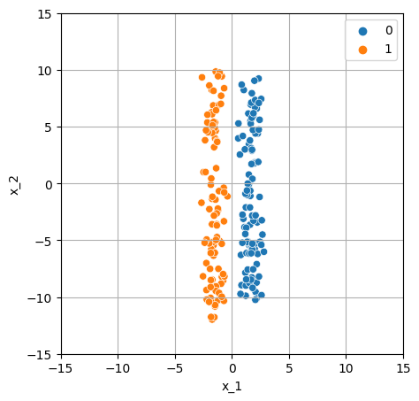

```python
plot_data_points(X, y, xlim=(-15, 15), ylim=(-15, 15))
```

Как видно, наши данные идеально разделяются прямой $x=0$

Функция $plot\_knn\_bound$ принимает на вход объекты $X$, метки классов $y$, метод нормализации признаков $scaler$, число соседей $n\_neighbors$ и границы рисунка $xlim$, $ylim$. Функция обучает $KNN$ классификатор с числом соседей $n\_neighbors$ и визуализирует разделяющую поверхность для классов, полученную с помощью обученного $KNN$ классификатора.

- Если вы не можете различить *выбранные нами цвета*, то измените список цветов в переменных cmap_light и cmap_bold. Актуальный список возможных цветов находится [здесь](https://matplotlib.org/stable/tutorials/colors/colormaps.html)

```python
from matplotlib.colors import ListedColormap
from sklearn import neighbors, datasets

def plot_knn_bound(X, y, scaler=None, n_neighbors=10, xlim=(-15, 15), ylim=(-20, 20)):
    # step size in the mesh
    h = 0.05

    # Create color maps
    cmap_light = ListedColormap(['C0', 'orange', 'cyan', 'green'][:np.unique(y).shape[0]])
    cmap_bold = ['C0', 'orange', 'c', 'darkgreen'][:np.unique(y).shape[0]]

    x_min, x_max = xlim
    y_min, y_max = ylim
    xx, yy = np.meshgrid(np.arange(x_min, x_max, h),
                         np.arange(y_min, y_max, h))
    grid = np.c_[xx.ravel(), yy.ravel()]

    X_scaled = X # if scaler is None
    if scaler is not None:
        grid = scaler.transform(grid)
        X_scaled = scaler.transform(X)

    # we create an instance of Neighbours Classifier and fit the data.
    clf = neighbors.KNeighborsClassifier(n_neighbors, algorithm='brute')
    clf.fit(X_scaled, y)

    Z = clf.predict(grid)

    # Put the result into a color plot
    Z = Z.reshape(xx.shape)
    plt.contourf(xx, yy, Z, cmap=cmap_light)

    # Plot also the training points
    sns.scatterplot(x=X[:, 0], y=X[:, 1], hue=y,
                    palette=cmap_bold, alpha=1.0, edgecolor="black")
    plt.xlabel('x_1')
    plt.ylabel('x_2')
    plt.title('Разделющие поверхности алгоритма {}-NN'.format(n_neighbors))
    plt.grid()
    plt.show()
```

Нарисуем разделющие поверхности $1$-$NN$ и $10$-$NN$

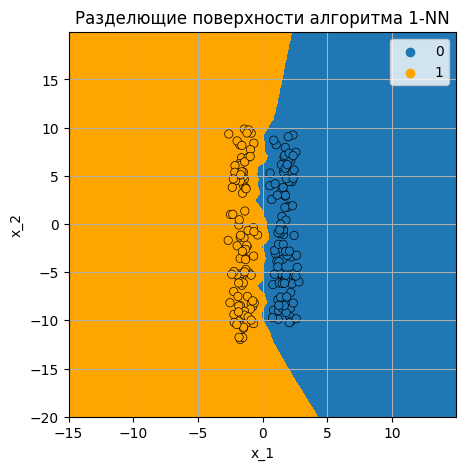

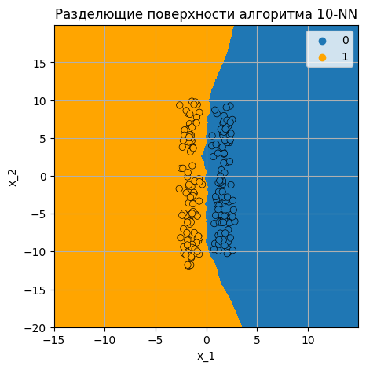

```python
plot_knn_bound(X, y, n_neighbors=1)
plot_knn_bound(X, y, n_neighbors=10)
```

**Задание 1.2** (кросс, 2 балла) Чем отличаются поверхности, полученные при числе соседей 1 и 10? Объясните, чем вызваны данные отличия

ВАШ ОТВЕТ: Поверхности, полученные при числе соседей 1 и 10 в алгоритме k-NN, отличаются в следующем:

1. Граница решения:
   - При числе соседей равном 1 (1-NN), каждая точка данных будет классифицироваться на основе единственного ближайшего соседа. Это означает, что граница решения будет очень сложной (ломаной) и может быть подвержена шуму в данных.
   - При числе соседей равном 10 (10-NN), каждая точка данных будет классифицироваться на основе 10 ближайших соседей. Это означает, что граница решения будет более сглаженной и устойчивой к выбросам и шуму в данных.
2. Ошибки и переобучение:
   - В случае 1-NN, модель может сильно реагировать на выбросы и малейшие шумовые колебания в данных. Это может привести к переобучению, когда модель слишком хорошо подстраивается под обучающие данные, но не обобщается хорошо на новые данные.
   - В случае 10-NN, модель более устойчива к выбросам и шуму, что делает ее менее склонной к переобучению. Она имеет более надежное обобщение и склонна к более стабильным результатам.

Таким образом, различия в границах решения при 1-NN и 10-NN обусловлены балансом между гибкостью и стабильностью модели, а также ее способностью к обобщению и вычислительной сложностью.

**Задание 1.3** (кросс, 3 балла) Объясните, почему наблюдается сильное отклоенние разделяющей поверхности от прямой $x_1=0$ при значениях $x_2 < -10$ и $x_2 > 10$. Дайте строгое математическое обоснование наблюдаемого явления, показывающее, что в Евклидовом пространстве данная проблема решается нормализацией признаков.

ВАШ ОТВЕТ:

1. Сильное отклонение разделяющей поверхности от прямой $x_1=0$ при значениях $x_2 < -10$ и $x_2 > 10$ может быть объяснено тем, что в алгоритме k-NN расстояние между точками сильно зависит от масштаба признаков. Если признаки имеют разные масштабы, то расстояния будут сильно искажены, и это может повлиять на границу решения. В данном случае $x_2$ варьируется намного сильнее $x_1$ (мы рассматриваем $x_2$ в диапазоне от -20 до +20, в то время как $x_1$ принимает значения примерно от -3 до +3).
2. Также стоит отметить, что все точки выборки сконценированы в диапазоне $x_2$ от -10 до +10, что позволяет более точно вычислить границу именно в этом диапазоне. В остальных же диапазонах (при $x_2 < -10$ и $x_2 > 10$) точки из выборки отсутствуют и вычислить точную границу невозможно.
3. Математически можно обосновать это следующим образом: Пусть у нас есть два признака $x_1$ и $x_2$, и расстояние между двумя точками в пространстве определяется как евклидово расстояние: $D = \sqrt[2]{(x1_1 - x1_2)^2 + (x2_1 - x2_2)^2}$ Если $x_2$ варьируется от -10 до 10, а $x_1$ варьируется от -3 до 3, то даже небольшие изменения в $x_2$ могут сильно влиять на значение расстояния D. Таким образом, точки с различными значениями $x_2$ будут иметь разные веса в алгоритме k-NN, и это может вызвать сильное отклонение границы решения.
4. Нормализация признаков позволяет уравнять масштабы, делая их сравнимыми. Это достигается путем преобразования признаков так, чтобы они имели среднее значение (матожидание) равное 0 и стандартное отклонение равное 1. Таким образом, нормализация приводит признаки к одному и тому же масштабу, что улучшает работу алгоритма k-NN и позволяет более адекватно учитывать все признаки при вычислении расстояний.
5. Итак, сильное отклонение разделяющей поверхности при $x_2 < -10$ и $x_2 > 10$ обусловлено различными масштабами признаков, и нормализация признаков позволяет устранить это и обеспечить более корректную классификацию.

Данную проблему может решить нормализация признакового пространства.

**Задание 1.4** (кросс, 1 балл) Начертите разделяющие поверхности для $KNN$, обученного на нормализованных признаках с помощью реализованных вами нормализаторов. Используйте функцию $plot\_knn\_bound$. Менять функцию $plot\_knn\_bound$ нельзя.

MinMaxScaler

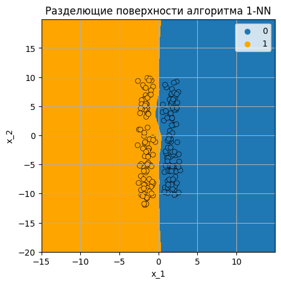

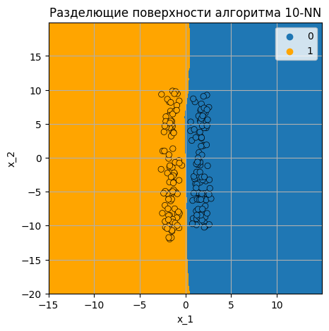

```python
scaler = MinMaxScaler()
scaler.fit(X)
plot_knn_bound(X, y, scaler=scaler, n_neighbors=1)
plot_knn_bound(X, y, scaler=scaler, n_neighbors=10)
```

StandardScaler

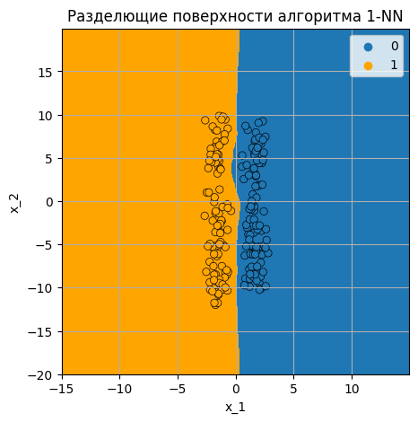

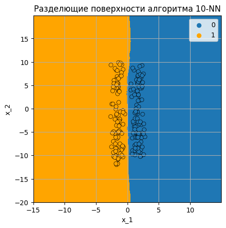

```python
scaler = StandardScaler()
scaler.fit(X)
plot_knn_bound(X, y, scaler=scaler, n_neighbors=1)
plot_knn_bound(X, y, scaler=scaler, n_neighbors=10)
```

**Задание 1.5** (кросс, 4 балла) Пусть дано произвольное число точек на плоскости. Представим, что каждая точка - это отдельный класс. Пусть на данной выборке был обучен $1-NN$ классификатор. Чем с геометрической точки зрения являются разделяющие поверхности этого классификатора? Требуется математически строго, однозначно и с полным обоснованием определить геометрическое место точек разделяющих поверхностей.

В качестве примера ниже представлена визуализация для четырех точек

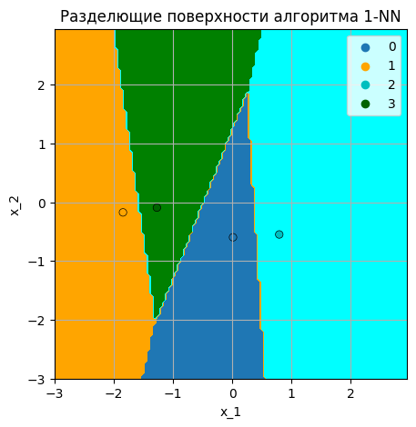

```python
X = np.random.randn(4, 2)
y = np.arange(4)
plot_knn_bound(X, y, n_neighbors=1, xlim=(-3, 3), ylim=(-3, 3))
```

ВАШ ОТВЕТ:

1. В примере на графике разделяющие поверхности являются геометрическим местом точек, равноудаленных от 2 ближайших соседей.
2. Обосновывая математически: разделяющие поверхности будут представлять собой прямые линии, которые проходят точно посередине между парами ближайших соседей. Поскольку каждая точка имеет только одного ближайшего соседа, то эта линия будет проходить посередине между этими двумя точками.
1. Для каждой точки данных (i-ой точки) на плоскости с координатами (x_i, y_i) рассмотрим, к какой другой точке данных (j-ой точке) она ближе всего с точки зрения евклидова расстояния. Пусть расстояние между i-ой и j-ой точками будет наименьшим, то есть d_ij - минимальным.
2. Разделяющая граница будет проходить посередине между i-ой и j-ой точками. Это следует из того, что в методе 1-NN классификация осуществляется на основе ближайшего соседа, и точка i будет классифицирована так, как классифицирован её ближайший сосед j. Поэтому разделяющая граница будет проходить точно посередине между i и j.
3. Математически, уравнение прямой, проходящей посередине между i и j, можно записать как:

   $$x = (x_i + x_j) / 2$$ $$y = (y_i + y_j) / 2$$

   Эти уравнения определяют середину отрезка между i и j, и разделяющая граница будет проходить через эту середину.

Таким образом, для метода 1-NN разделяющие границы будут прямыми линиями, проходящими посередине между каждой парой ближайших соседей. Это доказывает, что в приведенном коде разделяющие границы будут прямыми линиями, так как для каждой точки i они проходят между i и её ближайшим соседом j.

# Часть 2. Кросс-валидация на задаче регрессии

При решении прикладных задач, как правило, доступна лишь обучающая выборка. Для того чтобы иметь возможность оценить качество модели на тестовой выборке, прибегают к методу, называемому `кросс-валидация`.

Пусть зафиксирован некоторый набор гиперпараметров модели. В $KNN$ под гиперпараметрами могут пониматься число соседей, метрика близости $\rho$, стратегия выбора весов $w_i$.

- При кросс-валидации **обучающая** выборка делится на $n$ равных частей (folds).
- Затем обучаются $n$ моделей с заданными параметрами (у всех моделей параметры одинаковые и фиксированы) - $i$-ая модель обучается на всей обучающей выборке, кроме объектов, которые попали в $i$-ый фолд (out-of-fold).
- Затем измеряется качество $i$-ой модели на $i$-ом фолде. Так как он не участвовал в обучении этой модели, то полученная оценка качества модели будет являться корректной.
- Финальным значением метрики качества для модели с заданными параметрами является *среднее полученных нами значений* на $n$ фолдах.

*Подумайте, как в описанную выше схему корректно добавить обучение нормализаторов*

Принцип работы кросс-валидации схематично изображен на рисунке.

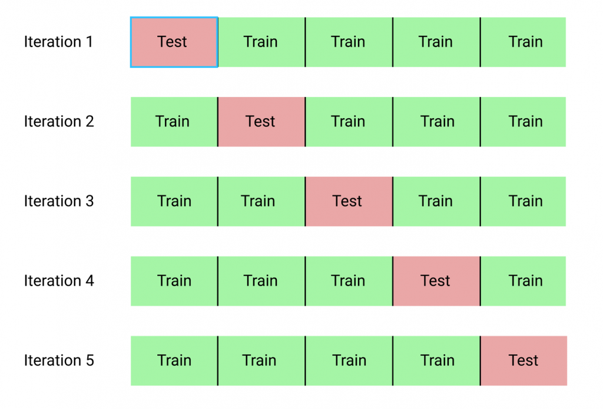

Небольшое видео объяснение о том, как работает кросс-валидация, можно посмотреть по [ссылке](https://www.youtube.com/watch?v=fSytzGwwBVw)

**Задание 2.1** (юнит-тесты, 12 баллов) В модуле cross_val.py реализуйте функции

- $kfold\_split$, которая реализует генерацию индексов обучающей и валидационной выборок для кросс-валидации
- $knn\_cv\_score$, которая реализует кросс-валидацию для $KNN-$модели

Далее будем решать задачу предсказания цены дома в Калифорнии с помощью $KNN$-регрессии. В качестве метрики качества будем использовать $R^2-$score.

$R^2(y\_true, y\_predict) = 1 - \frac{\sum_{i=1}^{n} (y\_true_i - y\_predict_i)^2}{\sum_{i=1}^{n} (y\_true_i - E(y\_true_i))^2}$

```python
from sklearn.datasets import fetch_california_housing
from sklearn.model_selection import train_test_split
```

```python
X, y = fetch_california_housing(return_X_y=True)
```

**Задание 2.2** (кросс, 2 балла) Разбейте выборку на обучающую (75%) и тестовую (25%) с помощью функции $train\_test\_split$. Используйте параметр **random_state=42!** Не забудьте перемешать данные перед разбиением (см. параметры функции). Запустите кросс-валидацию на 3 фолдах с помощью реализованных вами функций $kfold\_split$, $knn\_cv\_score$. В качестве метрики используйте $r2\_score$. Параметры для перебора описаны ниже

```python
# Разбиение данных на обучающую и тестовую выборки
X_train, X_test, y_train, y_test = train_test_split(X, y, test_size=0.25, random_state=42, shuffle=True)
```

```python
from sklearn.metrics import r2_score

parameters = {
    'n_neighbors': [1, 5, 10],
    'metrics': ['euclidean', 'cosine'],
    'weights': ['uniform', 'distance'],
    'normalizers': [(None, 'None'), (MinMaxScaler(), 'MinMax'), (StandardScaler(), 'Standard')]
}
score_function = r2_score
```

**После того, как вы локально реализовали и протестировали модуль cross_val.py, загрузите его в сессионное хранилище: нажмите знак папки слева, затем знак загрузки**

```python
from cross_val import kfold_split, knn_cv_score
from sklearn.neighbors import KNeighborsRegressor

# Количество фолдов
num_folds = 3

# Разделение обучающей выборки на фолды
folds = kfold_split(len(X_train), num_folds)

# Запуск кросс-валидации
results = knn_cv_score(X_train, y_train, parameters, score_function, folds, KNeighborsRegressor)
```

**Задание 2.3** (кросс, 2 балла) Какой наибольший $r2\_score$ удалось достичь на валидации? Какие закономерности вы видите? Обучите модель с наилучшими параметрами на всей обучающей выборке, измерьте $r2\_score$ на тестовой выборке.

Выведите результаты кросс-валидации

```python
# Поиск наилучших параметров
rating = sorted(results.items(), key=lambda x:x[1], reverse=True)
print(*rating, sep='\n')
```

```
(('MinMax', 10, 'euclidean', 'distance'), 0.7035316821435433)
(('MinMax', 5, 'euclidean', 'distance'), 0.6964752425342953)
(('MinMax', 10, 'euclidean', 'uniform'), 0.6955574490923349)
(('Standard', 10, 'euclidean', 'distance'), 0.691615057187545)
(('MinMax', 5, 'euclidean', 'uniform'), 0.6915621333110309)
(('Standard', 10, 'euclidean', 'uniform'), 0.6860471330995802)
(('Standard', 5, 'euclidean', 'distance'), 0.6834229913464561)
(('Standard', 10, 'cosine', 'distance'), 0.6829471618912982)
(('Standard', 5, 'euclidean', 'uniform'), 0.6793573692425973)
(('Standard', 10, 'cosine', 'uniform'), 0.6765890035252449)
(('Standard', 5, 'cosine', 'distance'), 0.666103286084983)
(('MinMax', 10, 'cosine', 'distance'), 0.6650747099452022)
(('Standard', 5, 'cosine', 'uniform'), 0.6639133943561187)
(('MinMax', 10, 'cosine', 'uniform'), 0.6595874224717159)
(('MinMax', 5, 'cosine', 'distance'), 0.6439729194747218)
(('MinMax', 5, 'cosine', 'uniform'), 0.6429483717302537)
(('MinMax', 1, 'euclidean', 'uniform'), 0.5329368736058075)
(('MinMax', 1, 'euclidean', 'distance'), 0.5329368736058075)
(('Standard', 1, 'euclidean', 'uniform'), 0.5139255367340351)
(('Standard', 1, 'euclidean', 'distance'), 0.5139255367340351)
(('Standard', 1, 'cosine', 'uniform'), 0.47958515234726945)
(('Standard', 1, 'cosine', 'distance'), 0.47958515234726945)
(('MinMax', 1, 'cosine', 'uniform'), 0.4590323476108448)
(('MinMax', 1, 'cosine', 'distance'), 0.4590323476108448)
(('None', 10, 'cosine', 'distance'), 0.40894335310524665)
(('None', 5, 'cosine', 'distance'), 0.3955985736693515)
(('None', 5, 'cosine', 'uniform'), 0.37805502479959713)
(('None', 10, 'cosine', 'uniform'), 0.3775295488771868)
(('None', 10, 'euclidean', 'distance'), 0.14310059566240177)
(('None', 5, 'euclidean', 'distance'), 0.1199731657678866)
(('None', 10, 'euclidean', 'uniform'), 0.1157913069850766)
(('None', 1, 'cosine', 'distance'), 0.1052704077615086)
(('None', 1, 'cosine', 'uniform'), 0.10527040776150857)
(('None', 5, 'euclidean', 'uniform'), 0.0977684191856583)
(('None', 1, 'euclidean', 'uniform'), -0.2698362539419594)
(('None', 1, 'euclidean', 'distance'), -0.2698362539419594)
```

ВАШ ОТВЕТ:

1. Лучшие параметры: ('MinMax', 10, 'euclidean', 'distance')
2. R2-оценка для лучших параметров: 0.7035316821435433
3. Сравнение нормализациия: Standard и MinMax в среднем дают одинаковый результат. И наличие одной из этих нормализаций дает намного более хороший результат, чем ее отсутствие.
4. Большее количество соседей тоже приводит к улучшению результата.
5. Выбор весов и метрик не содержит явной закономерности.

Обучите модель с лучшими по валидации параметрами на обучающей выборке

```python
# Использование лучших параметров
best_normalizer, best_n_neighbors, best_metric, best_weight = best_params
best_knn_model = KNeighborsRegressor(n_neighbors=best_n_neighbors, metric=best_metric, weights=best_weight)
if best_normalizer == "MinMax":
    best_normalizer = MinMaxScaler()
if best_normalizer == "Standard":
    best_normalizer = StandardScaler()

# Применение нормализации
if best_normalizer is not None:
    best_normalizer.fit(X_train)
    X_train_normalized = best_normalizer.transform(X_train)
    X_test_normalized = best_normalizer.transform(X_test)
else:
    X_train_normalized = X_train
    X_test_normalized = X_test

# Обучение модели
best_knn_model.fit(X_train_normalized, y_train)

# Прогнозирования на тестовой выборке
y_pred = best_knn_model.predict(X_test_normalized)

# Вычисление r2_score на тестовой выборке
test_r2_score = r2_score(y_test, y_pred)
print("R2-оценка на тестовой выборке:", test_r2_score)
```

```
R2-оценка на тестовой выборке: 0.7117082182374788
```

Результат: R2-оценка на тестовой выборке: 0.7117082182374788

# Часть 3. Работа с текстовыми данными

Далее будем решать задачу классификации новостного текста к одному из 20 классов, каждый класс соответствует определенной новостной тематике. В качестве метрики качества будем использовать $accuracy\_score$. Accuracy - это доля верно классифицированных объектов, среди всех объектов выборки.

```python
import numpy as np
from cross_val import kfold_split, knn_cv_score
from sklearn.neighbors import KNeighborsClassifier
from sklearn.datasets import fetch_20newsgroups
from sklearn.feature_extraction.text import CountVectorizer, TfidfVectorizer
```

```python
X_train, y_train = fetch_20newsgroups(subset='train', return_X_y=True, random_state=42)
X_test, y_test = fetch_20newsgroups(subset='test', return_X_y=True, random_state=42)
```

```python
print(X_train[0])
```

```
From: lerxst@wam.umd.edu (where's my thing)
Subject: WHAT car is this!?
Nntp-Posting-Host: rac3.wam.umd.edu
Organization: University of Maryland, College Park
Lines: 15

 I was wondering if anyone out there could enlighten me on this car I saw
the other day. It was a 2-door sports car, looked to be from the late 60s/
early 70s. It was called a Bricklin. The doors were really small. In addition,
the front bumper was separate from the rest of the body. This is
all I know. If anyone can tellme a model name, engine specs, years
of production, where this car is made, history, or whatever info you
have on this funky looking car, please e-mail.

Thanks,
- IL
   ---- brought to you by your neighborhood Lerxst ----
```

```python
X_train = np.array(X_train, dtype=object)
```

```python
X_test = np.array(X_test, dtype=object)
```

```python
y_train = np.array(y_train)
y_test = np.array(y_test)
```

Как мы видим, объектами обучающей выборки являются тексты. Сырые текстовые данные не могут служить обучающими примерами для алгоритма $KNN$. Перед использованием $KNN$ текстовые данные переменной длины необходимо отобразить в числовой вектор фиксированной размерности.

Работа с текстовыми данными проходит в несколько этапов.

- **Токенизация.** Текстовая строка делится на токены. Как правило, в качестве токенов выступают отдельные слова и знаки препинания.
- **Нормализация.** Приведение к нижнему регистру, удаление стоп-слов, удаление пунктуации, удаление редких и частотных слов и т.д.
- **Векторизация.** Фиксируется словарь токенов $V$ по **обучающей** выборке. Текст представлется в виде вектора длиной $|V|$, где каждый признак есть функция от частоты встречаемости токена в тексте и в обучающей выборке.

В данном задании будет использовано два вида векторизации. Первый, $CountVectorizer$, сопоставляет каждому токену частоту встречаемости этого токена в тексте документа. Второй, $TfidfVectorizer$, сопоставляет каждому токену частоту встречаемости этого токена в тексте документа умноженную на величину обратно пропорциональную частоте встречаемости токена во всех документах **обучающей** выборки. Подробне про $tf-idf$ можно прочитать [здесь](https://ru.wikipedia.org/wiki/TF-IDF). Более подробно про работу с текстами можно прочитать в [статье](https://habr.com/ru/companies/otus/articles/687796/) на Хабре и в [NLTK Book](https://www.nltk.org/book/).

В sklearn все векторизаторы автоматически токенизируют текст и приводят его к нижнему регистру. Параметры $max\_df$ и $min\_df$ позволяют убрать из словаря наиболее частые и наиболее редкие токены. Параметр $stop\_words$ позволяет убрать из словаря стоп-слова (малоинформативные слова для данного языка, например, союзы).

```python
count_vec = CountVectorizer(max_df=0.8, min_df=10, max_features=1000, stop_words='english')
tf_idf = TfidfVectorizer(max_df=0.8, min_df=10, max_features=1000, stop_words='english')
```

**Задание 3.1** (кросс, 2 балла) Найдите оптимальные параметры обучения модели. Осуществлять перебор параметров следует по заданной ниже сетке. Используйте реализованные вами функции $kfold\_split$, $knn\_cv\_score$. В качестве метрики используйте $accuracy\_score$. 3х фолдов для кросс-валидации будет достаточно.

```python
from sklearn.metrics import accuracy_score

parameters = {
    'n_neighbors': [i for i in range(1, 11)],
    'metrics': ['cosine'],
    'weights': ['uniform', 'distance'],
    'normalizers': [(count_vec, 'CountVectorizer'), (tf_idf, 'TfidfVectorizer')]
}
```

Если вы все сделаете правильно, то запущенная вами кросс-валидация будет работать примерно 7 минут. Дождитесь ее завершения, не закрывайте и не перезагружайте этот colab ноутбук.

```python
# Разделение данных на фолды
folds = kfold_split(len(X_train), 3)

# Использование knn_cv_score для поиска оптимальных параметров
optimal_parameters = knn_cv_score(X_train, y_train, parameters, accuracy_score, folds, KNeighborsClassifier)

# Поиск параметров с наилучшими показателями
par_sort = sorted(optimal_parameters.items(), key = lambda x:x[1], reverse=True)

print("Лучшие параметры:", par_sort[0])
```

```
Лучшие параметры: (('TfidfVectorizer', 1, 'cosine', 'uniform'), 0.6936529067480152)
```

1. Лучшие параметры: ('TfidfVectorizer', 1, 'cosine', 'uniform')
2. Лучший показатель точности: 0.6936529067480152

**Задание 3.2** (кросс, 2 балла) Какой метод предобработки данных в среднем дает наилучший результат? Почему?

```python
tfid = np.array([i[1] for i in par_sort if i[0][0] == 'TfidfVectorizer'], dtype=np.float64)
cnt = np.array([i[1] for i in par_sort if i[0][0] == 'CountVectorizer'], dtype=np.float64)

print('Среднее значение для TfidfVectorizer: ', tfid.mean())
print('Среднее значение для CountVectorizer: ', cnt.mean())
```

```
Среднее значение для TfidfVectorizer:  0.6626436330298413
Среднее значение для CountVectorizer:  0.6387355353440083
```

ВАШ ОТВЕТ:

1. В среднем лучший результат дает именно TfidfVectorizer
2. Часто встречающийся токен не несет большой вклад для определения класса данного документа. Также верно и обратное.
3. TfidfVectorizer учитывает эту особенность
4. CountVectorizer не учитывает

**Задание 3.3** (кросс, 2 балла) Начертите график зависимости метрики качества от числа соседей. Метрику следует усреднить по всем параматрам, кроме числа соседей. Сделайте выводы о наблюдаемых зависимостях (возможно будет полезным ознакомиться с названиями классов)

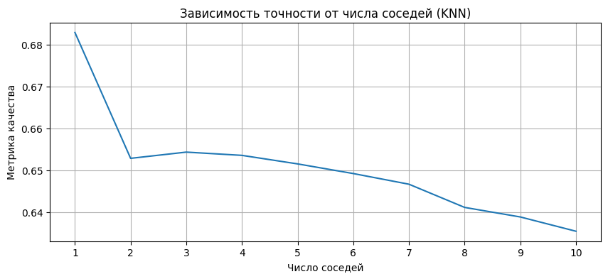

```python
import matplotlib.pyplot as plt

par_list = [[x[0], x[1], x[2], x[3], i] for x, i in par_sort]
neighbors_dict = {}

for i in par_list:
    neighbors = i[1]
    score = i[4]

    if neighbors in neighbors_dict:
        neighbors_dict[neighbors].append(score)
    else:
        neighbors_dict[neighbors] = [score]

neighbors = sorted(neighbors_dict.keys())
mean = [sum(neighbors_dict[n]) / len(neighbors_dict[n]) for n in neighbors]

plt.figure(figsize=(10, 4))
plt.plot(neighbors, mean)
plt.title('Зависимость точности от числа соседей (KNN)')
plt.xlabel('Число соседей')
plt.ylabel('Метрика качества')
plt.grid()
plt.xticks(neighbors)
plt.show()
```

ВАШ ОТВЕТ:

1. C ростом числа соседей метрика (в среднем) падает
2. Можно заметить, что у многих классы представляют одинавые темы.
3. Готов предположить, что имеено по этой причине с ростом числа соседей в целевую переменную добавляется шум, что негативно сказывается на качестве модели.

**Задание 3.4** (кросс, 3 балла) Оцените точность вашей лучшей модели на тестовой части датасета. Отличается ли оно от качества, полученного на кросс-валидации? Почему? При ответе на поставленные вопросы вам поможет анализ распределений обучающей и тестовой выборок

```python
# ('TfidfVectorizer', 1, 'cosine', 'uniform')
knn_model = KNeighborsClassifier(n_neighbors=1, weights='uniform', metric='cosine')

tf_idf.fit(X_train)
X_train_preprocessed = tf_idf.transform(X_train)
knn_model.fit(X_train_preprocessed, y_train)

X_test_preprocessed = tf_idf.transform(X_test)
y_pred = knn_model.predict(X_test_preprocessed)
result_score = accuracy_score(y_test, y_pred)


print('Точность на тестовой выборке: ', result_score)
```

```
Точность на тестовой выборке:  0.5315985130111525
```

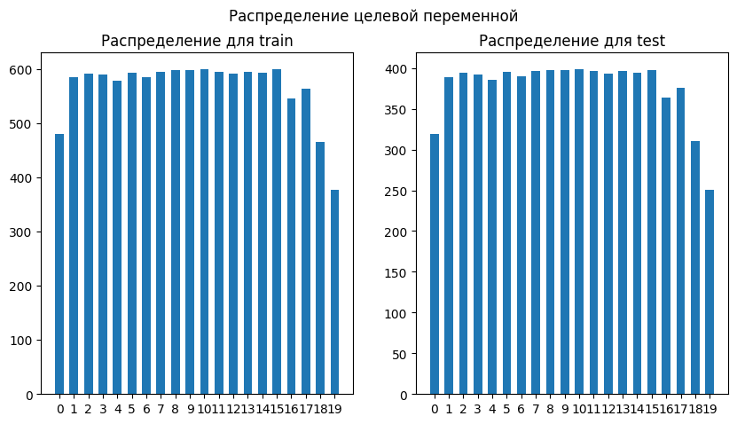

```python
fig, axes = plt.subplots(1, 2, figsize=(10, 5))
fig.suptitle('Распределение целевой переменной')

values_train, count_train = np.unique(y_train, return_counts=True)
axes[0].bar(values_train, count_train, width=0.6)
axes[0].set_title('Распределение для train')
axes[0].set_xticks(values_train)

values_test, count_test = np.unique(y_test, return_counts=True)
axes[1].bar(values_test, count_test, width=0.6)
axes[1].set_title('Распределение для test')
axes[1].set_xticks(values_test)

plt.show()
```

1. Полученный результат ~ в 1.3 раза меньше (в сравнении с кросс-валидацией)
2. Распределение целевой переменной в обучающей и тестовой выборках идентичны.
3. Вывод: падение качества модели на тестовой выборке обусловлено различным распределенем токенов на обучающей и тестовой выборках.